# 02: Day 2 Material

## General Introduction

Today we will briefly introduce some `geomorph` functions for performing the analyses described yesterday. **Note:** You should be able to read in your data and perform the analyses from yesterday! Thus this tutorial augments the ‘next steps’ of a morphometric analysis (i.e., we are beginning to flesh out the steps of the Procrustes Paradigm for geometric morphometric analyses).

## 1: Generalized Procrustes Analysis (GPA) with Sliding Semilandmarks

Below is a simple 2D example containing points and curves. For 3D we could add curves and/or surfaces (see help file)

```r
data(hummingbirds)
hummingbirds$curvepts
```

```
##       before slide after
##  [1,]      1    11    12
##  [2,]     11    12    13
##  [3,]     13    14    15
##  [4,]      7    15    14
##  [5,]     12    13    14
##  [6,]      1    16    17
##  [7,]     16    17    18
##  [8,]     17    18    19
##  [9,]     18    19    20
## [10,]     10    20    19
## [11,]      2    21    22
## [12,]     21    22    23
## [13,]     22    23    24
## [14,]     23    24    25
## [15,]      8    25    24
```

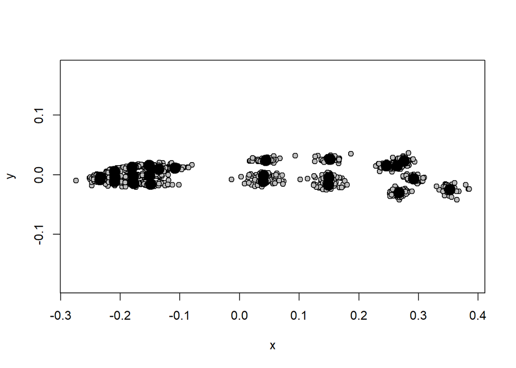

```r
gpa.BE <- gpagen(hummingbirds$land,
                 curves = hummingbirds$curvepts,
                 ProcD=FALSE,
                 print.progress = F)
plot(gpa.BE)
```

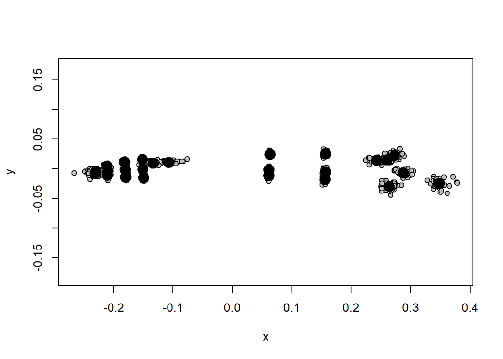

```r
gpa.procD <- gpagen(hummingbirds$land,
                    curves = hummingbirds$curvepts,
                    ProcD=TRUE, print.progress = F)
plot(gpa.procD)
```

##### NOTE: For StereoMorph users, the notation is slightly different for specifying curves (see help file):

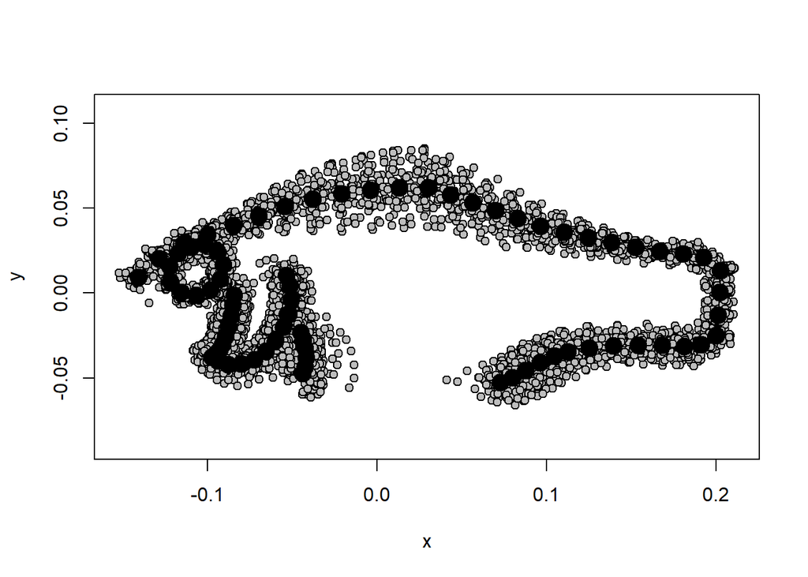

```r
shapes <- StereoMorph::readShapes("Data/example.digitized")
shapesGM <- readland.shapes(shapes,
  nCurvePts = c(12, 12, 12, 8, 6, 6, 6, 12, 10))

Y.gpa <- gpagen(shapesGM,
                print.progress = FALSE)
plot(Y.gpa)
```

## 2: Partial Least Squares (PLS)

Here is a simple example of partial least squares:

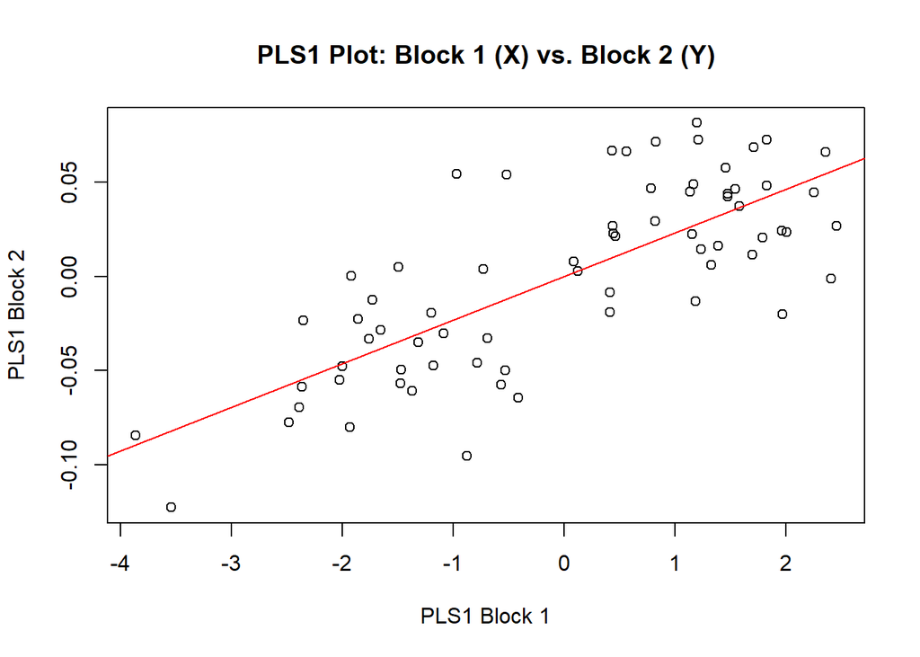

```r
data("plethShapeFood")
Y.gpa <- gpagen(plethShapeFood$land,
                print.progress = FALSE)

food <- plethShapeFood$food

rownames(food) <- names(Y.gpa$Csize) # just to assure match

PLSfood <- two.b.pls(food, Y.gpa$coords,
                     print.progress = FALSE,
                     iter = 9999)
plot(PLSfood)
```

## 3: GLM: Regression

Here is a simple example of regression from a linear model:

```r
fit.null <- procD.lm(coords ~ 1, data = Y.gpa,
                     iter = 9999)
fit.alt <- procD.lm(coords ~ log(Csize), data = Y.gpa,
                    turbo = FALSE, iter = 9999)
anova(fit.alt)
```

```
##
## Analysis of Variance, using Residual Randomization
## Permutation procedure: Randomization of null model residuals
## Number of permutations: 10000
## Estimation method: Ordinary Least Squares
## Sums of Squares and Cross-products: Type I
## Effect sizes (Z) based on F distributions
##
##            Df      SS       MS     Rsq      F      Z Pr(>F)
## log(Csize)  1 0.10758 0.107583 0.23511 20.594 5.3289  1e-04 ***
## Residuals  67 0.35001 0.005224 0.76489
## Total      68 0.45759
## ---
## Signif. codes:  0 '***' 0.001 '**' 0.01 '*' 0.05 '.' 0.1 ' ' 1
##
## Call: procD.lm(f1 = coords ~ log(Csize), iter
## = 9999, turbo = FALSE, data = Y.gpa)
```

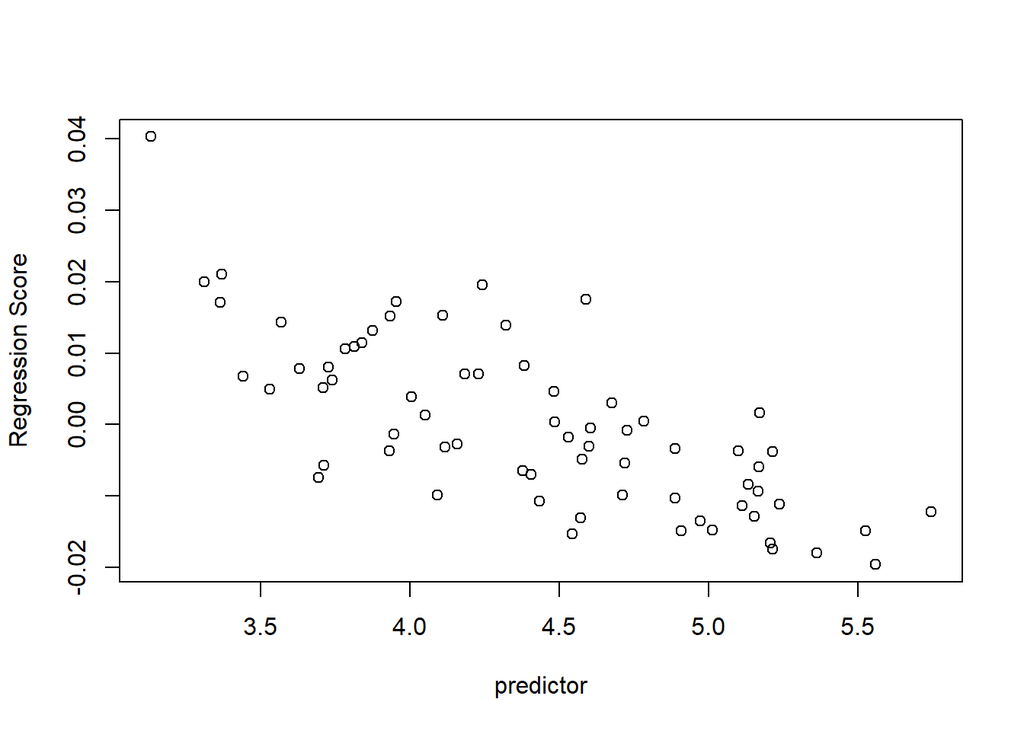

```r
plot(fit.alt, type = "regression",
     reg.type = "RegScore",
     predictor = Y.gpa$Csize)
```

## 4: Allometry

Here is a simple example of examining allometry:

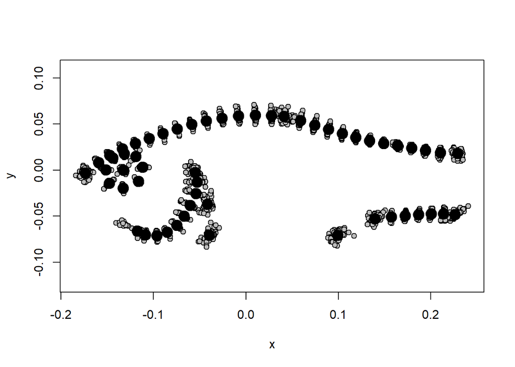

```r
data(pupfish)
plotAllSpecimens(pupfish$coords)  #NOTE: already GPA-aligned
```

```r
  #Y.gpa <- gpagen(pupfish$coords, print.progress = FALSE)    #GPA-alignment
pupfish$logSize <- log(pupfish$CS)
pupfish$Group <- interaction(pupfish$Pop, pupfish$Sex)

fit <- procD.lm(coords ~ logSize,
                data = pupfish,
                print.progress = FALSE)
anova(fit)
```

```
##
## Analysis of Variance, using Residual Randomization
## Permutation procedure: Randomization of null model residuals
## Number of permutations: 1000
## Estimation method: Ordinary Least Squares
## Sums of Squares and Cross-products: Type I
## Effect sizes (Z) based on F distributions
##
##           Df       SS        MS     Rsq      F      Z Pr(>F)
## logSize    1 0.014019 0.0140193 0.24886 17.229 4.3462  0.001 ***
## Residuals 52 0.042314 0.0008137 0.75114
## Total     53 0.056333
## ---
## Signif. codes:  0 '***' 0.001 '**' 0.01 '*' 0.05 '.' 0.1 ' ' 1
##
## Call: procD.lm(f1 = coords ~ logSize, data =
## pupfish, print.progress = FALSE)
```

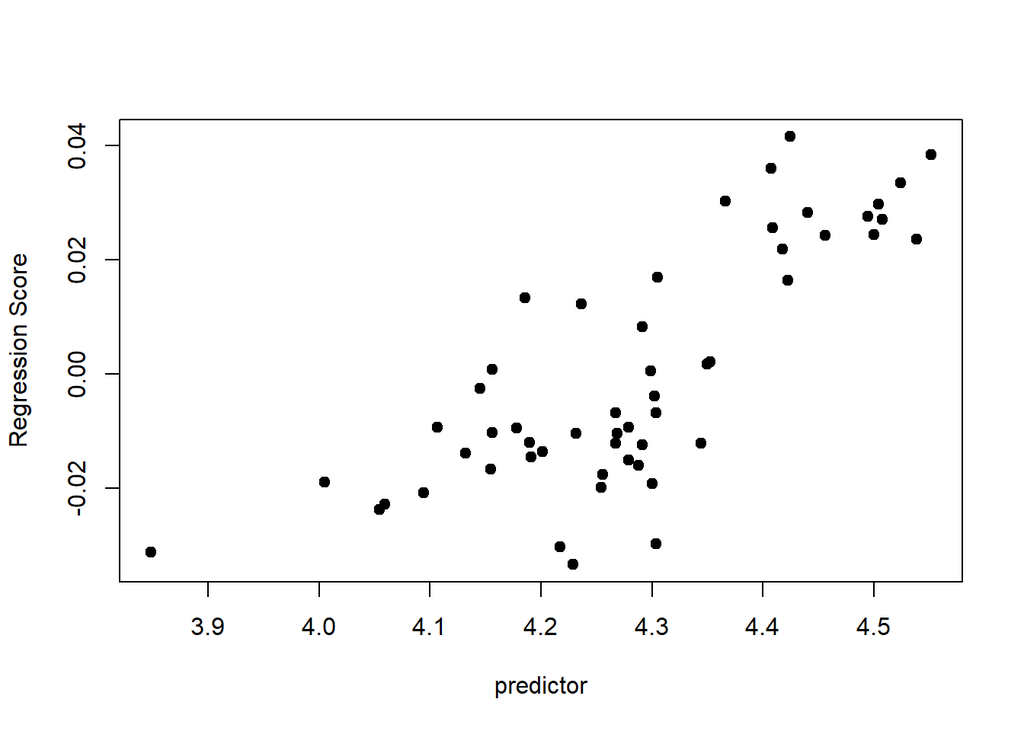

```r
plot(fit, type = "regression",
     reg.type = "RegScore",
     predictor = pupfish$logSize,
     pch = 19)
```

```r
  #NOTE: Try also: reg.type = "PredLine"
```

#### Comparing Allometric Trajectories

There are multiple ways to compare allometric trajectories. First we will compare a trajectory to some *a priori* vector using `betaTest`. Then we will compare trajectories to each other.

```r
data(plethodon)
Y.gpa <- gpagen(plethodon$land, print.progress = FALSE)
fit <- procD.lm(coords ~ log(Csize), data = Y.gpa, print.progress = FALSE)
bt <- betaTest(fit, coef.no = 2, Beta =  c(rep(0,24)))
summary(bt) #does not differ from isometry
```

```
## Test of coefficients: log(Csize)
##  equal to Beta = 0 0 0 0 0 0 0 0 0 0 0 0 0 0 0 0 0 0 0 0 0 0 0 0
##  Test performed with 1000 permutations of residuals from specified null models.
##
##                     d UCLd (95%)       Zd Pr(>d)
## log(Csize) 0.09442581  0.1069676 1.208273  0.122
```

```r
fit.common <- procD.lm(coords ~ logSize + Group,
                           data = pupfish, print.progress = FALSE)
fit.unique <- procD.lm(coords ~ logSize * Group,
                           data = pupfish, print.progress = FALSE)
anova(fit.unique)
```

```
##
## Analysis of Variance, using Residual Randomization
## Permutation procedure: Randomization of null model residuals
## Number of permutations: 1000
## Estimation method: Ordinary Least Squares
## Sums of Squares and Cross-products: Type I
## Effect sizes (Z) based on F distributions
##
##               Df       SS        MS     Rsq       F      Z Pr(>F)
## logSize        1 0.014019 0.0140193 0.24886 29.2078 5.0041  0.001 ***
## Group          3 0.018230 0.0060766 0.32361 12.6601 6.4893  0.001 ***
## logSize:Group  3 0.002004 0.0006682 0.03558  1.3921 1.1451  0.136
## Residuals     46 0.022079 0.0004800 0.39194
## Total         53 0.056333
## ---
## Signif. codes:  0 '***' 0.001 '**' 0.01 '*' 0.05 '.' 0.1 ' ' 1
##
## Call: procD.lm(f1 = coords ~ logSize * Group,
## data = pupfish, print.progress = FALSE)
```

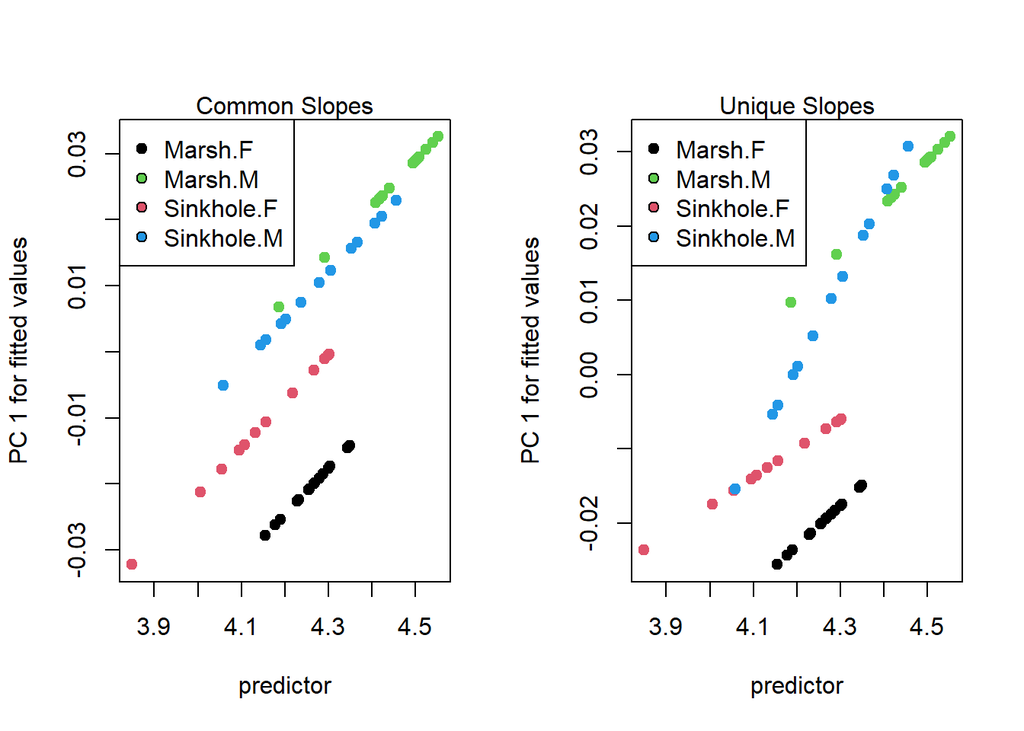

```r
par(mfcol = c(1, 2))

plot(fit.common, type = "regression",
     predictor = pupfish$logSize,
     reg.type = "PredLine",
     pch=19,
     col = pupfish$Group)

legend("topleft",
       legend = unique(pupfish$Group),
       pch = 21,
       pt.bg = unique(pupfish$Group))

mtext("Common Slopes")

plot(fit.unique,
     type = "regression",
     predictor = pupfish$logSize,
     reg.type = "PredLine",
     pch=19,
     col = pupfish$Group)

legend("topleft",
       legend = unique(pupfish$Group),
       pch = 21,
       pt.bg = unique(pupfish$Group))

mtext("Unique Slopes")
```

```r
par(mfcol = c(1, 1))
```

**Conclusion:** Not much going on for this example (**illustration purposes only**).

## 5: Things to Explore on Your Own

1. Remember Day 1 (read in your data, GPA, PCA, TPS)
2. Perform GPA + sliders
3. 3D data: Perform GPA with points, curves, surfaces, or some combination
4. Perform PLS: visualize shapes along PLS
5. Perform regression: visualize shapes along regression
6. Generate shapes for small and large specimens in an allometry analysis
7. **Explore function options and output** (there are many!)